# Raster-based landscape genomics simulations.

Peter Ralph

2015-12-27

Here’s a simple layer we’ll work with. Note that units are in meters.

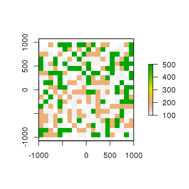

```r
habitat <- raster(xmn=-1000, xmx=1000, ymn=-1000, ymx=1000,
      resolution=100,
      crs="+proj=utm +zone=11 +ellps=GRS80 +towgs84=0,0,0,0,0,0,0 +units=m +no_defs")
values(habitat) <- sample( 100*c(1,2,5,NA), length(habitat), replace=TRUE )
plot(habitat,asp=1)
```

```r
# plotting function for typical layers below
pl <- function (x,nr=1,zlim,...) {
    if (missing(zlim)) {
        if (inherits(x,"Raster")) {
            zlim  <- c(0,max(values(x),na.rm=TRUE))
        } else if (inherits(x,"population")) {
            zlim  <- c(0,max(x$N,na.rm=TRUE))
        }
    }
    plot(x,nr=nr,zlim=zlim,...)
}
```

# A simulation step

Beginning with a population:

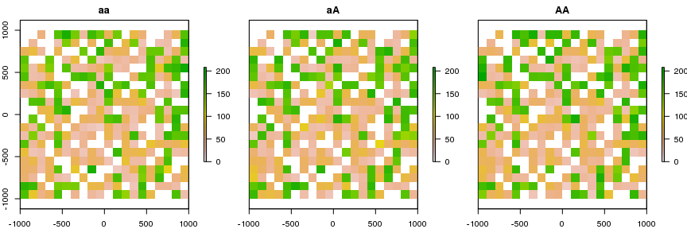

```r
N <- rpois_raster( brick( habitat, habitat, habitat )/3 )
genotypes <- names(N) <- c("aa","aA","AA")
pl(N)
```

Here are the population parameters. To maintain population densities, we’ll make the germination rate depend on the local population density. Concretely, let’s use something motivated by the Beverton-Holt model, which without age structure has $n' = r_0/(1/n+1/M)$, and carrying capacity $(r_0-1)M$: if $f(x)$ is the nearby population density (possibly smoothed somehow), then the germination rate is $r_0/(1+f(x)/M(x))$.

```r
# probability of seeding in a given year
prob.seed <- 0.2
# pollen dispersal kernel
pollen.kernel <- function (x) { exp(-sqrt(x)) }
pollen.sigma <- 100
max.pollen.dist <- 1000
# seed dispersal kernel
seed.kernel <- "gaussian"
seed.sigma <- 20
max.seed.dist <- 400
# number of seeds per individual
seed.fecundity <- 200
# genotype offspring tensor:
#  [i,j,k] is the probability that genotypes i and j combine to make offspring genotype k
mating.tensor <- array( c(
        # aa offspring
        1,   1/2,   0, # aa
        1/2, 1/4,   0, # aA
        0,     0,   0, # AA
        # aA offspring
        0,   1/2,   1, # aa
        1/2, 1/2, 1/2, # aA
        1,   1/2,   0, # AA
        # AA offspring
        0,     0,   0, # aa
        0,   1/4, 1/2, # aA
        0,   1/2,   1  # AA
        ), dim=c(3,3,3) )
dimnames(mating.tensor) <- list( genotypes, genotypes, genotypes )
# raw germination rate
prob.germination <- 0.01
# competition kernel for germination
competition.kernel <- "gaussian"
competition.sigma <- 100
max.competition.dist <- 300
# sort of carrying capacity
carrying.capacity <- habitat
# probability of survival
prob.survival <- 0.9
```

1. **Sample the number of seed-producing individuals:**

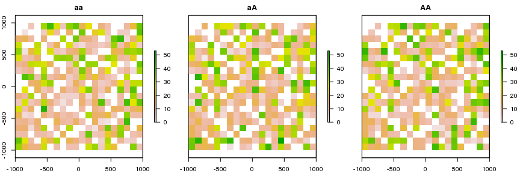

```r
M <- rbinom_raster(N,prob.seed)
pl(M)
```

2. **Find the mean pollen flux:**

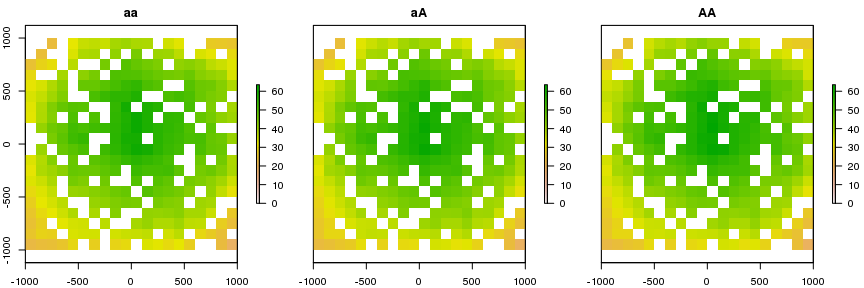

```r
P <- migrate_raster(N,kern=pollen.kernel,sigma=pollen.sigma,radius=max.pollen.dist)
pl(P)
```

3. **Find the mean seed production field:**

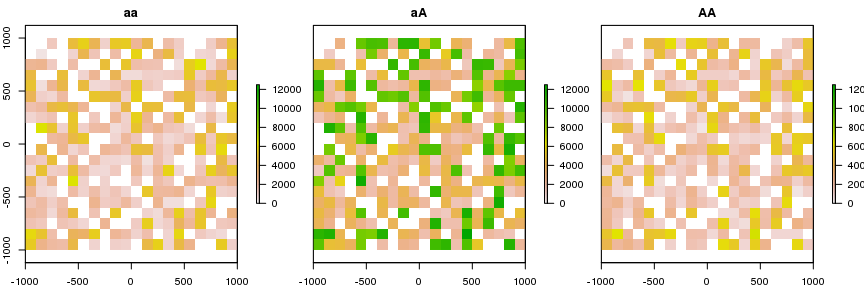

```r
S <- seed_production_raster(seeders=M,pollen=P,mating=mating.tensor,
                     fecundity=seed.fecundity)
pl(S)
```

4. **Disperse seeds:**

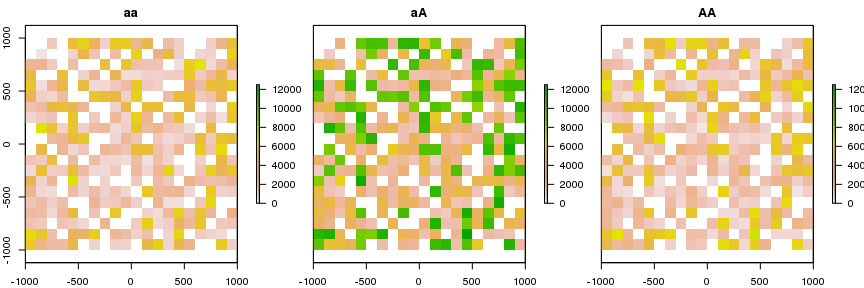

```r
SD <- migrate_raster(S,kern=seed.kernel,sigma=seed.sigma,radius=max.seed.dist,
                     normalize=TRUE)
pl(SD)
```

5. **Find competition kernel:** according to $r_0/(1+f(x)/M(x))$:

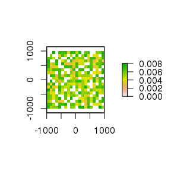

```r
K <- migrate_raster(sum(N),kern=competition.kernel,sigma=competition.sigma,
                    radius=max.competition.dist,normalize=TRUE)
K <- prob.germination/(1+K/carrying.capacity)
pl(K)
```

6. **Sample new individuals:**

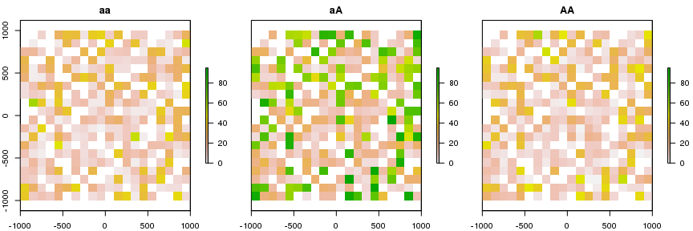

```r
G <- rpois_raster(SD*K)
names(G) <- names(SD) # multiplication removes names
pl(G)
```

7. **Kill off old individuals and add in new ones:**

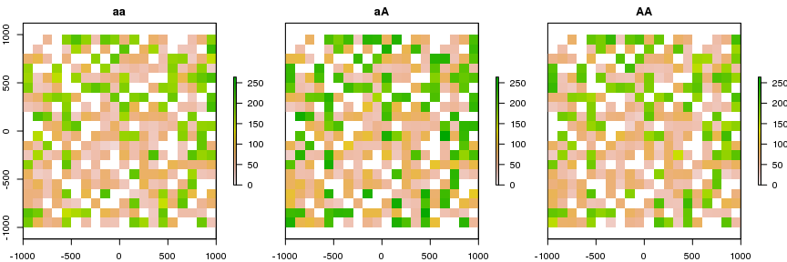

```r
NN <- rbinom_raster(N,prob.survival) + G
pl(NN)
```

# Demography set-up

Now, let’s use tools from the package to set up the simulation we ran above. The function that determines current germination probabilities is left *unspecified*, to be passed in at runtime, because it is a raster, and we want to demographic setup to be independent of the raster being used.

```r
germination.args <- list(
             r0 = 0.01,
             competition = migration(
                                     kern="gaussian",
                                     sigma=100,
                                     radius=300,
                                     normalize=1,
                                     do.M=TRUE,
                                     population=habitat
                                 )
         )
germination_fun <- function (N, carrying.capacity, ...) {
    germination.args$r0 / ( 1 + migrate(rowSums(N),germination.args$competition)/carrying.capacity )
}

this.demography <- demography(
        prob.seed = 0.2,
        fecundity = 200,
        prob.germination = germination_fun,
        prob.survival = 0.9,
        pollen.migration = migration(
                            kern = function (x) { exp(-sqrt(x)) },
                            sigma = 100,
                            radius = 1000,
                            normalize = NULL,
                            do.M=TRUE,
                            population=habitat
                     ),
        seed.migration = migration(
                            kern = "gaussian",
                            sigma = 20,
                            radius = 400,
                            normalize = 1,
                            do.M=TRUE,
                            population=habitat
                     ),
        genotypes = c("aa","aA","AA"),
        mating = mating_tensor( c("aa","aA","AA") )
    )
```

## Demography application

Now, doing the above simulation step is just a matter of calling `generation()`. **Importantly**, note that we pass in `carrying.capacity`, since it was left unspecified in the function `germination_fun` above.

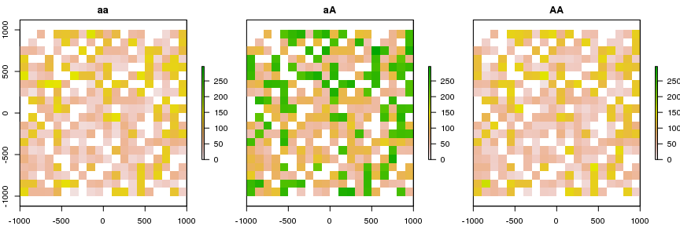

```r
pop <- population(
                  habitat = habitat,
                  genotypes = c("aa","aA","AA"),
                  N = cbind( aa=rpois_raster(habitat/4,only.values=TRUE),
                             aA=rpois_raster(habitat/2,only.values=TRUE),
                             AA=rpois_raster(habitat/4,only.values=TRUE) )
             )

pl(pop)
```

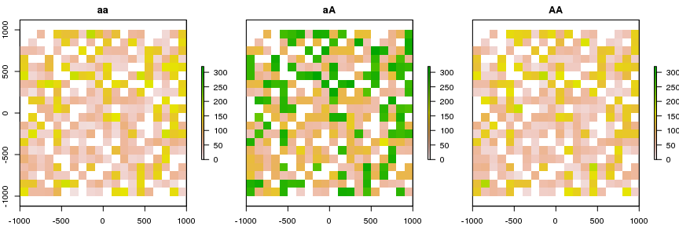

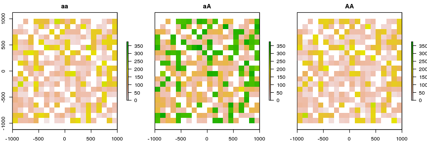

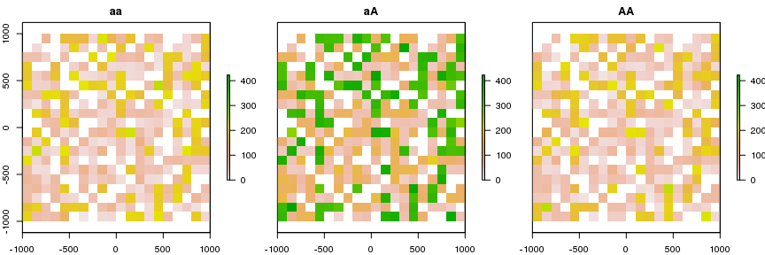

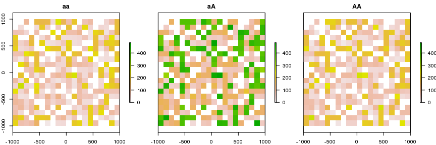

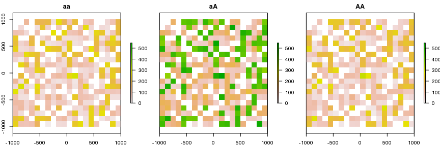

```r
for (k in 1:5) {
    pop$N <- generation(pop,this.demography,carrying.capacity=values(pop$habitat)[pop$habitable])
    pl(pop)
}
```